# Estimating Pro-War and Anti-War Sentiments by State Using Multilevel Regression with Poststratification

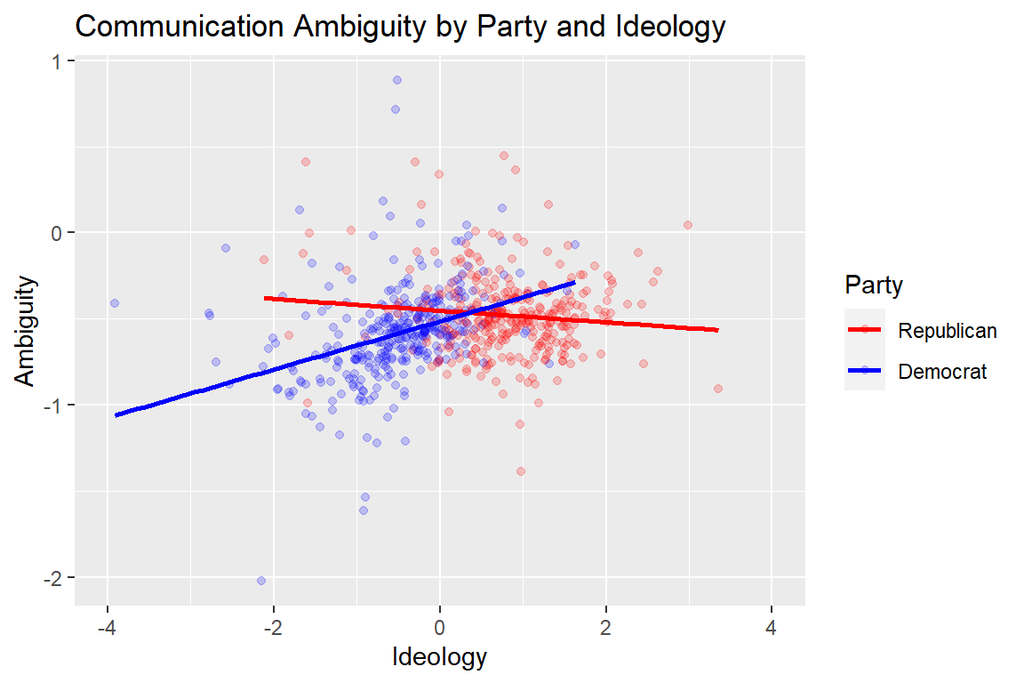

Scatterplot of Communication Ambiguity by Ideology, Grouped by Partisanship

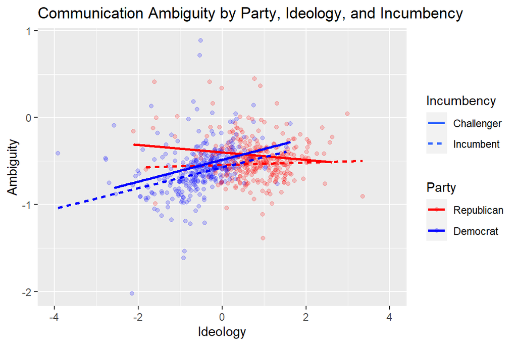

Scatterplot of Communication Ambiguity by Ideology, Grouped by Partisanship and Incumbency

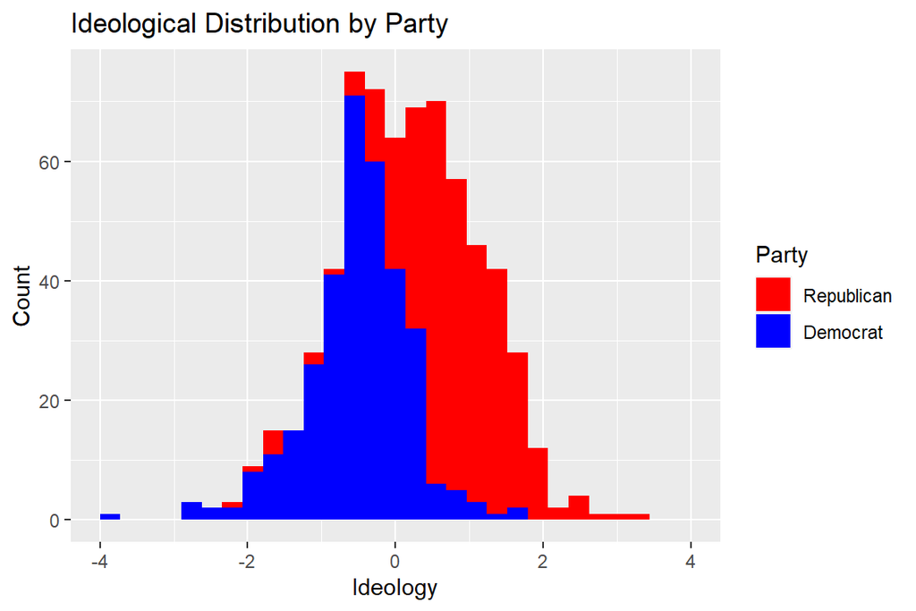

Ideological Distribution by Party

This exploratory analysis of the relationship between party, ideology, and their effect on ambiguity was particularly important due to the strong but incomplete correlation of partisanship and ideology. We felt that using both ideology and party as a fixed effect may cause multicollinearity when we were originally creating our model. However, our correlation tests, plots, and further analysis have suggested that using both variables would not create a multicollinearity problem. In addition, both variables play an important part in profiling a candidate and explaining ambiguity in their messaging. Table 2 shows that incumbent Republicans and Democratic challengers have very similar mean ambiguity scores.

Summary Statistics of Ambiguity, Grouped by Partisanship and Incumbency

| Democrat | Incumbent | Mean Ambiguity | Standard Deviation of Ambiguity | Minimum Ambiguity | Maximum Ambiguity | Number |
| --- | --- | --- | --- | --- | --- | --- |
| 0 | 0 | -0.4231988 | 0.2134283 | -1.0396 | 0.4120 | 161 |
| 0 | 1 | -0.5294059 | 0.2415471 | -1.3868 | 0.4444 | 170 |
| 1 | 0 | -0.5255372 | 0.1900786 | -1.2198 | 0.0434 | 188 |
| 1 | 1 | -0.6633632 | 0.3457776 | -2.0206 | 0.8850 | 144 |

One important dimension of the political data set focuses on the political characteristics of the district. Some of these variables are important to predict political ambiguity. For instance, we might predict that districts that are more polarized might have more ambiguity in their politicians. In districts with higher levels of polarization, or in districts that have a greater variety in political ideologies, we might expect that there is a different level of ambiguity in a politician. Therefore, it may be important to observe different district level variables.

First, we will construct numerous plots to observe the different variables at a district leve, in order to understand their distribution and the relationship that these variables have with ambiguity. These resulting figures are shown in Figure 7. District Lean, Attitude Heterogeneity and Demographic Heterogeneity all have a roughly normal distribution. District Demographic Heterogeneity and District Lean both appear to have skews, with District Lean having a skew towards liberal ideologies, and a skew towards districts with more Demographic Heterogeneity. In these graphs, we are able to see a few weaker, general trends. We can see that there is no clear correlation between ambiguity and District Lean, or District Attitude Heterogeneity and Ambiguity. However, the District Demographic Heterogeneity appears to have a relationship with the ambiguity, so we might consider adding that variable.

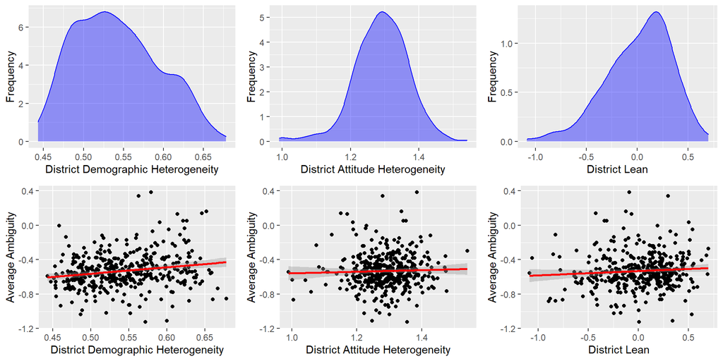

Analyzing Frequency and Trends of District-Level Variables in Relation to Ambiguity

### Methods

To evaluate different models, we have used the AIC and BIC values. These values show us how much variability in a model is accounted for, while penalizing the use of additional variables. We decided that the best model minimizes these AIC and BIC terms compared to other models. In addition, the model that we want to choose would investigate the relationships with ambiguity that we have previously identified. We started with a baseline unconditional means model. From there, we decided to include additional terms, as this improved the AIC and BIC of our model. An ideal model for this report would reduce the AIC and BIC relative to other models, while addressing the effect on ambiguity of candidate’s party, ideology, the number of issue pages and demographic heterogeneity.

With only two observations per district, any random slope would be created from only those two observations and thus any random slope term would be inappropriate to apply to this dataset. Therefore, we choose to use a random effect term for District, instead of any other random effects or slopes.

First, we identified that we wanted to use a model that included ideology and the incumbent status of the candidate. Then, we additionally recognized that the variable for demographic heterogeneity was important in predicting the ambiguity of a candidate’s position. Figure 7 shows a positive correlation between District Demographic Heterogeneity and Ambiguity. We also found a relationship between the number of issue pages and the ambiguity of a candidate. This model minimized AIC and BIC more than any other model that we tried.

Finally, we included an interaction term between ideology and the candidate’s party. This was based on Figure 4, which shows a relationship between the candidate’s party and ideology. Therefore, we have a model, where i represents district and j represents the candidate:

This will create a model that has an AIC of approximately -42.68, and a BIC of approximately -2.209. These are remarkably small values for AIC and BIC compared to the other models that we tried to make. Some models had slight improvements on AIC, but these results were often only a small improvement on AIC, and a significant reduction in effectiveness for BIC. In addition, this model tested the relationships that we wanted to investigate.

$$\begin{align}
Y_{ij}&=[\alpha_{0}+\beta_{0}\text{ideology}_{ij}+\beta_{1}\text{ideology}_{ij}\times\text{democrat}_{ij}+\beta_{2}\text{democrat}_{ij}+\beta_{3}\text{incumbent}_{ij}\\
&+\beta_{4}\text{Dem.Heterogeneity}_{i}+\beta{5}\text{TotalIssuePages}_{ij}]+[u_{i}+\epsilon_{ij}]
\end{align}$$

where, $u_i\sim N(0,\sigma^2_u)$ and $\epsilon_{ij}\sim N(0,\sigma^2)$.

$\alpha_0$ is the variable that indicates the ambiguity we expect for challengers who are republican, in districts with a value of demographic heterogeneity of zero and there are no pages. This is not a valuable measure, because we do not expect there to be a case where this reflects a real scenario.

$\beta_0$ represents the expected change that we would see in ambiguity scores for a one-point increase in ideology score for republicans, all other variables held constant. Likewise, $\beta_1$ represents the expected change that we would see in ambiguity scores for a one-point increase in ideology score for democrats, all other variables held constant. $\beta_2$ represents the difference between democrats and republicans for candidates with ideology scores of zero, all else held equal.

$\beta_3$ represents the expected change that we would see in ambiguity scores for incumbents, when compared to challengers, all else held equal. $\beta_4$ represents the change that we would expect in ambiguity scores as the Demographic Heterogeneity increases by a score of one within a district. Finally, $\beta_5$ represents the change in ambiguity scores as the total number of issue pages is increased by one for a candidate, all else held equal.

### Results

Variance and Covariance Estimates for Random Effects

| Group | Var. 1 | Var. 2 | Variance | Standard Deviation |
| --- | --- | --- | --- | --- |
| distID | (Intercept) | NA | 0.0001 | 0.0079 |
| Residual | NA | NA | 0.0504 | 0.2244 |

Estimates of Fixed Effects

|  | Estimate | Std. Error | df | t value | Pr(>\|t\|) |
| --- | --- | --- | --- | --- | --- |
| (Intercept) | -0.7493 | 0.1001 | 435.5119 | -7.4831 | 0.0000 |
| ideology | 0.0129 | 0.0174 | 654.7179 | 0.7434 | 0.4575 |
| democrat1 | -0.0479 | 0.0238 | 555.7621 | -2.0118 | 0.0447 |
| incumbent | -0.1175 | 0.0186 | 495.6615 | -6.3230 | 0.0000 |
| demHeterogeneity | 0.8153 | 0.1768 | 409.8686 | 4.6115 | 0.0000 |
| totalIssuePages | -0.0155 | 0.0017 | 655.7906 | -9.0158 | 0.0000 |
| ideology:democrat1 | 0.1010 | 0.0253 | 648.0790 | 3.9880 | 0.0001 |

The model estimates that Republican challengers with no issue pages, an ideology of 0, running in a district with no demographic heterogeneity will have communication ambiguity of -0.749305. For each additional point in ideology for Republicans, the model estimates a 0.012945 point increase in communication ambiguity after accounting for all other fixed effects. However, it should also be noted that this result is not statistically significant, with a large p-value of 0.45. Democrats are estimated to have communication ambiguity 0.047871 less than Republicans after accounting for all other fixed effects. Incumbents are estimated to have communication ambiguity 0.117505 less than challengers after accounting for all other fixed effects. For each additional point in a district’s demographic heterogeneity, the model estimates a 0.815260 point increase in communication ambiguity after accounting for all other fixed effects. For each additional issue page on a candidate’s website, the model estimates a 0.015542 point decrease in communication ambiguity after accounting for all other fixed effects. For each additional point in ideology, the model estimates that Democrats have an additional 0.100959 point increase in communication ambiguity over Republicans. The model estimates that the standard deviation in communication ambiguity across districts is 0.007862 after accounting for all fixed effects.

### Discussion and Conclusions

In this paper, we saw that ambiguity does differ with an interaction between a candidate’s party identification and their ideology. Given a p-value of roughly zero for `ideology:democrat`, we feel confident that Republicans have a different change in ambiguity depending on ideology than Democrats. The estimate for this variable is 0.100959 and indicates that Democrats become more ambiguous per increase in ideology than Republicans. This connects to the theory from Milita, Simas, Ryan, and Krupnikov (2017) that depending on party, candidates may feel more comfortable with the idea that voters rely on party heuristics when faced with ambiguous language. Our results add evidence to Shesle’s research that incumbents tend to have greater clarity than challengers overall, potentially because they are constrained by past voting behavior, greater media scrutiny, and previous position statements (Shepsle, 1972). The model estimate for `incumbent` is -0.117505, with a p-value of nearly zero, indicating we can be very confident incumbents tend to be more clear. Our model does agree with and provide further evidence to Chap et al. that as a district becomes more demographically heterogeneous, ambiguity increases. We see an estimate of 0.815260 for `demHeterogeneity` and a p-value that was roughly zero. Finally, we see statistical evidence of a relationship between the number of issue pages on a candidate’s website and less ambiguous language, albeit not a dramatic decrease. The estimate for `totalIssuePages` is -0.015542 with a p-value of approximately zero. This answers our last research question following (Drucker et al. 2004) who concluded that there is little political incentive to address an issue ambiguously when avoidance will do. When candidates do address an issue, they are more likely to be clear about it.

Studies of ambiguity in political communication could benefit from a greater understanding of political success with our research questions in mind. Since the primary driver for most politicians is to win the election, it would be fascinating to consider vote shares between candidates. Other interesting directions for this research would be to compile data from many more election cycles to track individual candidates, parties, and other variables over time. This could add nuance to interactions between party and ideology depending on broader public opinion on generic ballots and control of the white house. For example, a party in 2014 may have been okay with voters relying on heuristics, if the public attitudes towards them were favorable, and opted for more ambiguous language. But generally opinions change for parties and candidates, especially depending on who controls the white house.

It is clear that certain candidate- and district-level factors lead to more ambiguous political communications. Going forward, it may be beneficial to our democracy to consider what, if any, constituent-induced factors contribute to the ambiguity of a candidate’s communications. That research may give greater agency to voters to shape political discussions and help strengthen our democracy.

### References

Chapp, C., Roback, P., Johnson-Tesch, K., Rossing, A., & Werner, J. (2019). Going Vague: Ambiguity and Avoidance in Online Political Messaging. Social Science Computer Review, 37(5), 591–610.

Downs, A. (1957). An economic theory of democracy. New York: Harper.

Druckman, J. N., Hennessy, C. L., Kifer, M. J., & Parkin, M. (2010). Issue engagement on congressional candidate web sites, 2002—2006. Social Science Computer Review, 28(1), 3-23.

Druckman, J. N., Jacobs, L. R., Ostermeier, E. (2004). Candidate strategies to prime issues and image. The Journal of Politics, 66, 1205–1227.

Krupnikov, Y., Ryan, J. B. (2017). Choice vs. action: Candidate ambiguity and voter decision making. Quarterly Journal of Political Science, 12, 479–505.

Mansbridge, J. (2003). Rethinking representation. American political science review, 97(4), 515-528.

Milita, K., Simas, E., Ryan, J., Krupnikov, Y. (2017). The effects of ambiguous rhetoric in congressional elections. Electoral Studies, 46, 48–63.

Shepsle, K. A. (1972). The strategy of ambiguity: Uncertainty and electoral competition. The American Political Science Review, 66, 555–568.

Tomz, M., Van Houweling, R. P. (2009). The electoral implications of candidate ambiguity. American Political Science Review, 103, 83–98.

## Appendix

[1] For more information on the specific methodology of their textual analysis, the original paper of Wordscores may be of interest. From that paper: “The ultimate methodological price to be paid for the benefits of a posteriori interpretation is the lack of any objective criterion for deciding between rival spatial interpretations, in situations in which the precise choice of interpretation can be critical to the purpose at hand. The price for taking the a priori route, on the other hand, is the need to accept take-it-or-leave-it propositions about the number and substantive meaning of the policy dimensions under investigation. Using the a priori method we introduce here, however, this price can be drastically reduced. This is because, once texts have been processed, it is very easy to re-estimate their positions on a new a priori dimension in which the analyst might be interested. For this reason we concentrate here on estimating positions on a priori policy dimensions.”

[2] In some of our data wrangling, we chose to switch the sign of the ambiguity variable in the dataset. Previously, it was higher scores that indicated higher clarity. However, because ambiguity is the response variable and the variable is titled ‘ambiguity’ we thought it made more sense for analysis to switch these around.

This is important for two reasons: First, any outside analysis that a person sees about Wordscores software will seem to draw the opposite conclusions; this is not the case, but the language prioritizes clarity over ambiguity. And second, this mutation was made after beginning work on our graphics and may not be reflected as clearly as possible in our analysis. This footnote serves to hopefully dispel any confusion.